# Submission Process for NCI’sU4C Prize Competition

2015-10-27

[figure not shown]

- A workspace that allows you to **aggregate,** **describe,** and **share** research
- A tool to **improve reproducibility** of data intensive science, recording progress as you work
- A set of **living research projects** enabling contribution to large-scale collaborative solutions
- Freely available to anyone

## Synapse for U4C

Up for a Challenge **requires** reproducibility and sharing of results and **encourages** collaboration across disciplines.

**These are the things that Synapse was designed to support.**

[figure not shown]

## Synapse for U4C

### Creating a Submission

We assume (and will not cover today) that:

1. You have registered for a free [Synapse account](https://www.synapse.org)
2. You have [registered for the Challenge](https://www.synapse.org/#!Synapse:syn3157598/wiki/232614)
3. You have (optionally) [formed and registered a Team](https://www.synapse.org/#!Synapse:syn3157598/wiki/232615)
4. You are familiar with the [rules for the Challenge](https://www.synapse.org/#!Synapse:syn3157598/wiki/232619)
5. You have [access to dbGaP data](https://www.synapse.org/#!Synapse:syn3157598/wiki/232632)

**All information can be found at the Challenge website:**

https://www.synapse.org/upforachallenge

## Synapse for U4C

### Creating a Submission

https://www.synapse.org/upforachallenge

1. Create a new Synapse Project
2. Find the [Project Submission Template](https://www.synapse.org/#!Synapse:syn4935464/wiki/235791)
3. Get the Wiki text from the template and copy it to your own Project Wiki
4. Create necessary Folders
5. Edit your Project Wiki (and other Project content) with your own content

Detailed information about these steps is available in section  
[4.5 - How to Submit A Challenge Entry](https://www.synapse.org/#!Synapse:syn3157598/wiki/232617).

## Synapse for U4C

### Creating a Submission Live Demo

Details are available at [4.5 - How to Submit A Challenge Entry](https://www.synapse.org/#!Synapse:syn3157598/wiki/232617)

## Synapse for U4C

### Creating a Submission

Before we explore an [Example Project Submission](https://www.synapse.org/#!Synapse:syn4154450/), I'll discuss features provided by Synapse to create a sharable, reusable, and reproducible Submission.

## Synapse Features

### Wikis

[figure not shown]

- We use a simple text-based formatting system called [Markdown](https://www.synapse.org/#!Synapse:syn2467792)
- You will use this to edit your Project Wiki with the content of your Submission

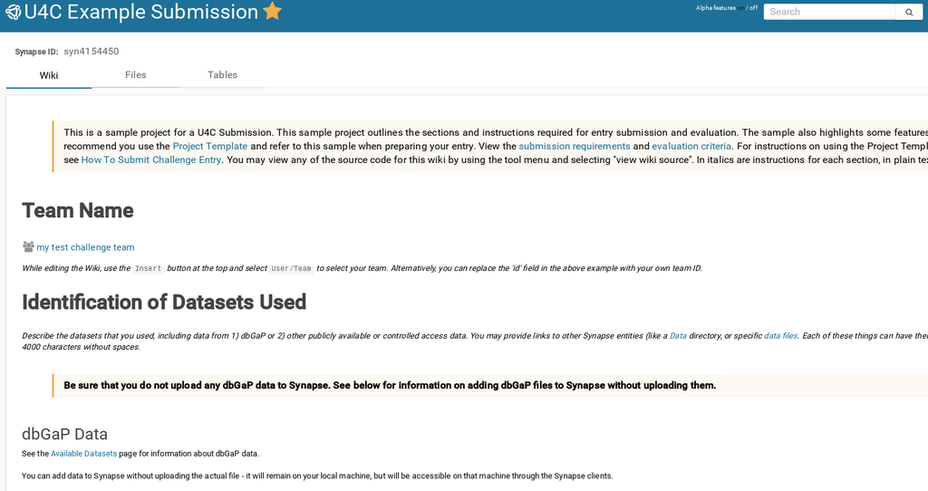

## Synapse features

### File storage

[figure not shown]

[figure not shown]

## Synapse features

### Storing data using the web interface

[figure not shown]

## Synapse features

### Linking to dbGaP data

**For this Challenge, dbGaP data cannot be uploaded to Synapse.**

However, a file can be linked instead of stored, and can still be used by many features of Synapse.

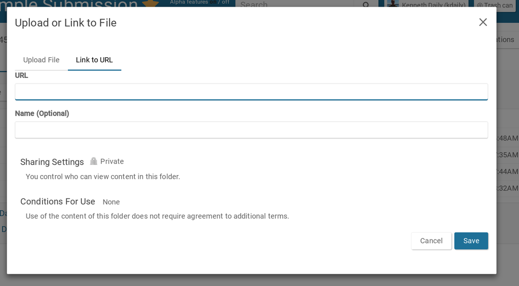

## Synapse features

### Certified user

[figure not shown]

**In order to add content to Synapse, [Take the Quiz](https://www.synapse.org/#!Quiz:Certification) to become a Certified User!**

## Synapse features

### Annotations

- Easily curate and search for specific files and folders
- Completely user-driven
- A querying system to search

[Example File with annotations](https://www.synapse.org/#!Synapse:syn4157529)

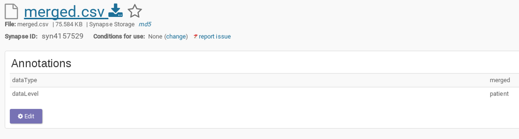

## Synapse features

### Provenance

[figure not shown]

**Provenance = keeping track of inputs, outputs, and the code to run**

- Who did what to a file and when?
- Retrieve in a computer-friendly manner
- Do it while you work or later in the browser

## Synapse features

### [Visualizing provenance in the browser](https://www.synapse.org/#!Synapse:syn4157529)

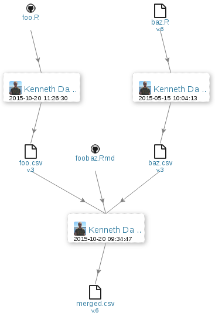

## Synapse features

### Synapse API

All features in the web browser are available from  
[`R`](https://www.synapse.org/#!Help:RClient), [`Python`](http://python-docs.synapse.org/), and the [`Command line`](https://www.synapse.org/#!Help:CommandLineClient) for use in an  
automated, reproducible manner.

[figure not shown]

## Synapse for U4C

### Example Project Submission

Let's explore the [Example Project Submission](https://www.synapse.org/#!Synapse:syn4154450/) to see how to the features of Synapse in action.

## Synapse for U4C

### Example Project Submission Live Demo

An [Example Project Submission](https://www.synapse.org/#!Synapse:syn4154450/) to highlight ways that you can use the features of Synapse to make your submission reproducible and sharable.

1. Note that you can see how to implement any of the features described in the example project by clicking "View Wiki Source"
2. Highlight examples on putting data (including dbGaP data linked) including code
3. Go to Data folder, show table
4. Go to dbGaP data folder and file, show that the file is not uploaded
5. Back at example project, show provenance examples

## Example public Projects

### For inspiration of Synapse features

- [AMP AD Knowledge Portal](https://www.synapse.org/#!Synapse:syn2580853)
- [Progenitor Cell Biology Consortium](https://www.synapse.org/#!Synapse:syn1773109)
- [JWGray Breast Cancer Cell Line Panel](https://www.synapse.org/#!Synapse:syn2346643)

For more, see [Research Communities](https://www.synapse.org/#!Synapse:syn3722562/wiki/219258) and [Open Resources](https://www.synapse.org/#!Synapse:syn3722562/wiki/219259).

## Synapse for U4C

### Submitting a Challenge Entry

See [4.5 - How to Submit A Challenge Entry](https://www.synapse.org/#!Synapse:syn3157598/wiki/232617), "How to Submit"

## Synapse for U4C

### Submitting a Challenge Entry Live Demo

1. Go to [4.5 - How to Submit A Challenge Entry](https://www.synapse.org/#!Synapse:syn3157598/wiki/232617), "How to Submit"
2. Click `Submit to Challenge` button
3. Find your Project
4. Choose the U4C challenge
5. Provide a name (same as your Project title)
6. Choose submitting as indiv or team (I'll choose team)
7. Submit!
8. Check that your submission appears in the submissions list
9. `Share` your project with the `NCI U4C Evaluation Panel` - they require view permissions
10. Potentially share your project with the public, whenever you want!

## Thank you!

### Questions?

- Leah Mechanic, [National Cancer Institute](http://epi.grants.cancer.gov/staff/mechanic.html)
- Elizabeth Gillanders, [National Cancer Institute](http://epi.grants.cancer.gov/staff/gillanders.html)
- Sara Lindström, [University of Washington](http://sph.washington.edu/faculty/fac_bio.asp?url_ID=Lindstroem_Sara)
- Thea Norman, [Sage Bionetworks](https://www.sagebase.org/)
- Solly Sieberts, [Sage Bionetworks](https://www.synapse.org/#!Profile:273959)
- Jay Hodgson, [Sage Bionetworks](https://www.synapse.org/#!Profile:345424)

## Advanced Synapse features

- Tables
- More annotations
- RMarkdown to Synapse Wikis (knit2synapse)

## Synapse features

### Structured data tables

- Data that is queryable, but also enforces the data type is stored in each column
- Can share a link to the results of a specific query.
- Can use results in Wiki, from programmatic clients

Example query:

```
SELECT UID,biologicalSampleName,Diffname_short,pass_qc,Cell_Type
FROM syn3156503
WHERE public=true
```

## Synapse features

### Annotations

- User-structured metadata directly on files/folders
- No types enforced like columns in table

```r
q <- "select * from file where projectId=='syn2346643' and dataSubType=='cna'"
res <- synapseQuery(q)
```

[output not shown]

## Wikis from RMarkdown

### Sage-Bionetworks/knit2synapse

- Run RMarkdown code directly to a Wiki (includes images, code, text)
- An [Example](https://www.synapse.org/#!Synapse:syn4157539)

```
library(knit2synapse)
knitfile2synapse("./foobaz.Rmd", owner="syn4157539", overwrite=TRUE)
```

- Can do similar thing with IPython notebooks